# 聚类分析

Zehui Bai

Stand: 2020-06-12 15:40 Uhr

# 1 Introduction

有一个响应变量Y，Y是X的函数，或表示为 y = f(x)。我们的数据中有Y的实际值，以Y为依据训练X。这种方式称为监督式学习。但是，我 们从数据中学习知识的时候通常没有响应变量Y，或者故意忽略了Y。此时就进入无监督学习 的世界。在这个世界里，我们建立和选择算法的基准是算法能够明确满足业务需求的程度，而 不是算法的正确率。

无监督学习可以帮助你理解并识别出数据中的模式，这可 能非常有价值。其次，你可以通过无监督学习转换数据，提高监督式学习技术的效果

聚类分析的目标是将 观测分成若干组（k个组），使同一组内的成员尽可能相似，不同组间的成员尽可能不同. 我们将重点讨论两种最常用的技术：层次聚类和 K均值聚类。它们都是非常有效的聚类方法，但如果你要分析的是大规模的高复杂度的数据集， 它们可能不太适合。所以，我们还要研究围绕中心点的划分，它使用基于果瓦度量的相异度矩阵作为输入。最后讨论一种我最近才学习和使用的新技术——使用随机森林转换数据。转换后的数 据可以用作无监督学习的输入。

## 1.1 层次聚类

层次聚类算法的基础是观测之间的相异度测量。我们使用的是通用的测量方式——欧氏距 离，当然还有其他方式。层次聚类是一种凝聚式的或自底向上的技术。首先，所有观测都是自己本身的一 个簇；然后，算法开始在所有的两点组合之中进行迭代搜索，找出最相似的两个 簇，将它们聚集成一个簇。所以，第一次迭代之后，有n 1个簇；第二次迭代 之后，有n 2个簇，依此类推

进行迭代时，除了距离测量之外，还有一个重要问题是需要确定观测组之间的测距方式，不 同类型的数据集需要使用不同的簇间测距方式

常用的测距方式类型:

- Ward距离, 使总的簇内方差最小，使用簇中的点到质心的误差平方和作为测量方式
- 最大距离（Complete linkage), 两个簇之间的距离就是两个簇中的观测之间的最大距离
- 质心距离（Centroid linkage), 两个簇之间的距离就是两个簇的质心之间的距离

dist()函数计算距离: 默认方式欧氏距离, 可以在这个函数中指定其他距离计算方式（如最大值距离、 曼哈顿距离、堪培拉距离、二值距离和闵可夫斯基距离）。

最后需要注意的是，要对你的数据进行标准化的缩放操作，使数据的均值为0， 标准差为1，这样在计算距离时才能进行比较。否则，变量的测量值越大，对距 离的影响就越大。

## 1.2 K均值聚类

使用K均值聚类时，需要明确指定所需的簇的数目，然后算法开始迭代，直到每个观测都属 于某个簇。算法的目标是使簇内的差异最小，簇内差异由欧氏距离的平方定义。所以，第k个簇 的簇内差异等于簇内所有两个观测之间的欧氏距离的平方和，再除以簇内观测的数量

迭代过程:

```
1. 设定:你需要的簇的确切数量(k)。
2. 初始化:随机选择k个观测作为初始均值。
3. 迭代:
   将每个观测分配给离它最近的簇中心点(使簇内平方和最小)，建立k个簇;
   将每个簇的中心点作为新的均值;
   重复上面两个步骤，直至收敛，即簇中心点不再改变。
```

因为第1步中的初始分配是随机的，所以会造成每次聚类结果不一致。因此，重要 的一点是，要进行多次初始分配，让软件找出最优的解。

## 1.3 果瓦系数与围绕中心的划分

无论层次聚类还是K均值聚类，都不是 为分析混合数据(既包括定量数据又包括定性数据)而专门设计的

```
使用果瓦相异度系数将混合数据转换为适当的特征 空间。在这种方法中，你甚至可以使用因子作为输入变量
处理混合数据，比 如可以先进行主成分分析, 建立潜变量，然后使用潜变量作为聚类的输入
聚类算法使用 PAM聚类算法，而不是K均值, PAM和K均值很相似, 有两个明显的优点
    1. PAM可以接受相异度矩阵作为输入，这样即可处理混合数据
    2. PAM对于异常值和不对称数据的鲁棒性更好，因为它最小化的是相异度总和，而不是欧氏距离的平方和
```

### 1.3.1 相异度矩阵 dissimilarity matrix

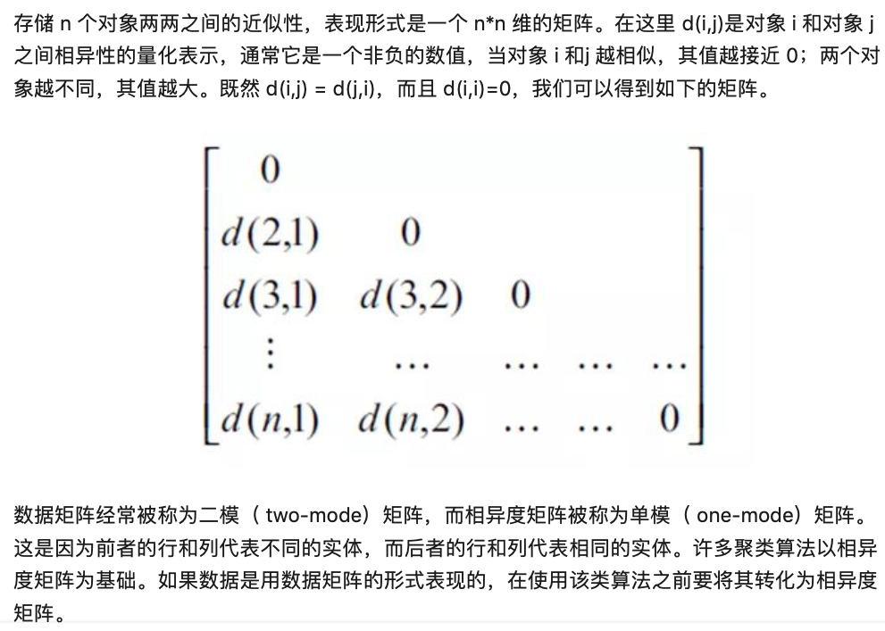